# The Application of Bayesian Analytical Methods to Cardiovascular Clinical Trials: Why, When, and How: JACC Review Topic of the Week

Case Study: MINT under the Bayesian Lens.

Author

Affiliation

Arthur M. Albuquerque (arthur_albuquerque1@yahoo.com)

Universidade Federal do Rio de Janeiro, Brazil

Published

January 20, 2024

Software: R

# **Overview of the trial and intervention**

“Restrictive or Liberal Transfusion Strategy in Myocardial Infarction and Anemia”

MINT, 2023

DOI: 10.1056/NEJMoa2307983

Primary endpoint: 30-day death or MI

Intention-to-treat analysis

3504 patients

P.S.: The restrictive strategy is the control arm. An OR greater than 1 represents that the liberal strategy is better than restrictive.

# **Formulating prior based on previous randomized clinical trials**

Let’s load all packages, import data from previous RCTs on the same topic and outcome, and meta-analyze these results to create a literature-based prior.

```r
##First, we will conduct a meta-analysis of the 3 prior RCTs. This meta-analysis will form the basis of our subsequent prior

#Load the packages & functions that we will need for this analysis
require("brms")
require("tidybayes")
require("dplyr")
require("ggplot2")
require("ggridges")
require("ggpubr")
require("ggthemes")
require("bpp")
require("foreach")
require("MetBrewer")
require("gt")
require("tidyr")

# Set global options to suppress Stan verbose output
options(stan.verbose = FALSE)

#Trial 1: Cooper et al., 2011 ("Death or recurrent myocardial infarction at 30 days"; Table 3 from DOI: 10.1016/j.amjcard.2011.06.014)
copper2011 <- data.frame(
  study = "Cooper et al., 2011", #Trial name
  total_n = c(24, 21), #Total sample size in each group
  events_n = c(2, 2), #Patients with an event in each group
  restrictive = c(0.5, -0.5) #Restrictive (Yes/No)
)

#Trial 2: MINT pilot, 2013 ("Death/MI" within 30 days; Table 3 from DOI: 10.1016/j.ahj.2013.03.001
mint_pilot <- data.frame(
  study = "MINT pilot", #Trial name
  total_n = c(54, 55), #Total sample size in each group
  events_n = c(12, 6), #Patients with an event in each group
  restrictive = c(0.5, -0.5) #Restrictive (Yes/No)
)


#Trial 3: REALITY ("All-cause death" + "Nonfatal recurrent myocardial infarction" within 30 days; Table 3 from DOI: 10.1001/jama.2021.0135)
reality <- data.frame(
  study = "REALITY", #Trial name
  total_n = c(342, 324), #Total sample size in each group
  events_n = c(26, 35), #Patients with an event in each group
  restrictive = c(0.5, -0.5) #Restrictive (Yes/No)
)

#Combine the data from the 3 trials into a single dataframe
combined_data <- rbind(copper2011, mint_pilot, reality)

#Now, we will write the formula we will use in the regression model
ma_formula <- bf(
  events_n | trials(total_n) ~ 0 + #Remove the intercept from the model (such that the risk of Death/MI is not modeled using a common term but is modeled separately for each study)
    factor(study) + #A term to refer to each study
    restrictive + #Treatment effect of Restrictive strategy
    (restrictive - 1|study) #Random effects (so as to not assume Restrictive has the same effect in every trial)
)

##Now, we will set up our priors (on the log-odds scale)

#Prior for the Treatment effect of restrictive (a normal distribution with a mean of 0 and a standard deviation of 10 implies we do not have any pre-existing information outside these trials for how beneficial or harmful this type of strategy may be)
restrictive_prior <- prior(normal(0, 10), class = b, coef = "restrictive")

#Prior for the Baseline risk of MI/Death (this prior is vague, since we could not find any large registry informing the risk of this outcome in this population. For further details on why this prior is vague, check "Chapter 11: GOD SPIKED THE INTEGERS" in the Statistical Rethinking book by Richard McElreath, 2nd edition.
baseline_risk_prior <- prior(normal(0, 1.5), class = b)

#Prior for between-trial Heterogeneity (this prior expresses our uncertainty about how similar trials are to one another in terms of the effectiveness of the restrictive strategy. A half-cauchy with a scale parameter of 0.5 represents a common choice in most meta-analyses)
heterogeneity_prior <- prior(cauchy(0, 0.5), class = sd)

#Now, we will collect these priors together and store them in "ma_priors" (ma: meta-analysis)
ma_priors <- c(restrictive_prior, baseline_risk_prior, heterogeneity_prior)

#Because Bayesian analyses can be somewhat time-consuming, we will use all the cores our machine has to increase computational speed
options(mc.cores = parallel::detectCores())

if(!exists("ma_model")) {
#Run the model incorporating both the prior you chose and the data at hand
ma_model <- brm(data = combined_data, #Use the combined dataset for the 6 trials
               family = binomial, #Using a binomial distribution (Since our outcome is a binary Stroke/No stroke)
               formula = ma_formula, #Use our formula
               seed = 100, #Set seed for reproducibility
               prior = ma_priors, #Use our prior
               control = list(adapt_delta = 0.99),
               backend = "cmdstanr",
               refresh = 0
               )
}
```

```
Running MCMC with 4 chains, at most 8 in parallel...

Chain 1 finished in 0.5 seconds.
Chain 2 finished in 0.5 seconds.
Chain 3 finished in 0.5 seconds.
Chain 4 finished in 0.5 seconds.

All 4 chains finished successfully.
Mean chain execution time: 0.5 seconds.
Total execution time: 0.7 seconds.
```

```r
#Store a summary of this model
sum_ma_model <- summary(ma_model)

#Get the parameters of the row which corresponds to the treatment (restrictive)
ma_restrictive_par <- sum_ma_model$fixed[rownames(sum_ma_model$fixed) == "restrictive", ]

##Store relevant variables
treatment_effect = fixef(ma_model) |> tail(1)

#The log odds ratio
ma_restrictive_lnor = round(treatment_effect[,"Estimate"],2)
#Standard error of the log odds ratio
ma_restrictive_lnor_sd = round(treatment_effect[,"Est.Error"],2)
#The odds ratio
ma_restrictive_or <- round(exp(treatment_effect[,"Estimate"]), 2)
#The lower limit of the 95% credible interval of the odds ratio
ma_restrictive_or_lci <- round(exp(treatment_effect[,"Q2.5"]), 2)
#The upper limit of the 95% credible interval of the odds ratio
ma_restrictive_or_uci <- round(exp(treatment_effect[,"Q97.5"]), 2)
```

This is a forest plot depicting all included RCTs and the overall effect size derived from the Bayesian random-effects meta-analysis.

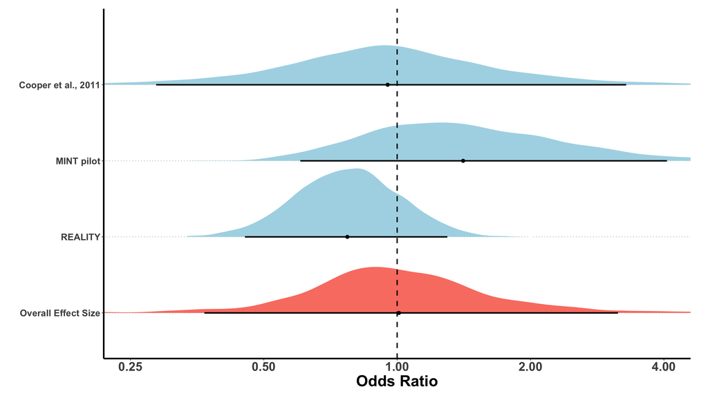

```r
##Figure 1

#Sample the posterior distribution of study-level estimates and the overall estimate of treatment effect
study_es <- ma_model %>%
  spread_draws(r_study[study, ], b_restrictive) %>%
  mutate(b_restrictive = r_study + b_restrictive, #Create treatment effect estimates for each study
         type = "Study-level estimate") #Clarify that this is the treatment effect for each study
pooled_es <- spread_draws(ma_model, b_restrictive) %>%
  mutate(study = " Overall Effect Size", #Clarify that this is the pooled/overall treatment effect
         type = "Pooled estimate") #Same

#Exponentiate to get odds instead of log-odds ratio
fp_data <- bind_rows(study_es, pooled_es) %>%
  mutate(b_restrictive = b_restrictive %>% exp,

         # Fix study names
         study = case_when(
           study == "Cooper.et.al." ~ "Cooper et al., 2011",
           study == "MINT.pilot" ~ "MINT pilot",
           TRUE ~ study
         ),

         # Reorder studies chronologically
         study = factor(study, level = c(" Overall Effect Size",
                                         "REALITY",
                                         "MINT pilot",
                                         "Cooper et al., 2011"))
         )


#Plot
ggplot(data = fp_data,
       aes(y = study,
           x = b_restrictive,
           fill = type
)) +
  #Add Density plots
  stat_halfeye(.width = 0.95,
               point_interval = mean_qi) +
    geom_vline(xintercept = 1, color = "black",
             lwd = 1, linetype = 2) +
  #Set colors
  scale_fill_manual(values = c("salmon", "lightblue")) +
  #X and Y axes aesthetics
  scale_y_discrete(name = "Study") +
  scale_x_continuous(name = "Odds Ratio",
                     trans = "log",
                     breaks = c(0.25, 0.5, 1, 2, 4)) +
  #Set reasonable Y axis limits
  coord_cartesian(xlim = c(0.25, 4)) +
  #Set theme
  theme_pubclean() +
  theme(text = element_text(size = 23),
        plot.title=element_text(face = "bold",hjust = 0.0, size = 20),
        plot.subtitle = element_text(face = "bold", size = 15, hjust = 0.0, color = "grey45"),
        axis.text.x = element_text(size = 20, face = "bold"),
        axis.text.y = element_text(size = 15, face = "bold"),
        axis.title.x = element_text(size = 25, face = "bold"),
        axis.title.y = element_blank(),
        axis.line = element_line(colour = "black", linewidth = 1.2),
        plot.margin = margin(0.5, 1, 0.5, 1, "cm"),
        legend.background = element_rect(fill = "transparent"),
        legend.position = "none",
        legend.text = element_text(size = 12, face = "bold"),
        legend.key.width = unit(1.5, "cm"),
        legend.key.height = unit(0.75, "cm"))
```

# **Analyzing MINT in light of prior evidence**

Next step is to import data from MINT’s primary outcome and analyze it using the literature-based prior shown above. The following code also shows calculations on the MCID that will be assessed later below.

```r
##We will now analyze the results of MINT using the results of our previous meta-analysis as input

#First, let us build the data for the MINT trial: Myocardial infarction or death within 30 days; Figure 2 from DOI 10.1056/NEJMoa2307983)
mint_data <- data.frame(
  study = "MINT", #Trial name
  total_n = c(1749, 1755), #Total sample size in each group
  events_n = c(295, 255), #Patients with Death/MI in each group
  restrictive = c(1, 0) #restrictive (Yes/No)
)

#The next steps are as before: first we specify the formula we will be using and then we specify the priors to be used for our analysis


#Now, we will write the formula we will use in the regression model
mint_formula <- bf(
  events_n | trials(total_n) ~
    1 + #Add an intercept to our model (for the baseline risk in the control group)
    restrictive) #Treatment effect of restrictive

##Now, we will set up our priors (on the log-odds scale)

# Literature-based prior for the Treatment effect of restrictive
mint_data_restrictive_prior <- prior(normal(ma_restrictive_lnor, ma_restrictive_lnor_sd), class = b, coef = "restrictive")

#Prior for the Baseline risk of Death, MI (this is the same as that used for the meta-analysis).
baseline_prior <- prior(normal(0, 1.5), class = Intercept)

#Combine these 2 priors into the same object
mint_priors <- c(mint_data_restrictive_prior, baseline_prior)

if(!exists("mint_model")) {
#Run the model incorporating both the prior from the meta-analysis and the data from MINT
mint_model <- brm(data = mint_data, #Use the dataset from MINT
               family = binomial, #Using a binomial distribution (Since our outcome is a binary Stroke/No stroke)
               formula = mint_formula, #Use our formula
               seed = 100, #Set seed for reproducibility
               prior = mint_priors, #Use the prior based on the meta-analysis
               stanvars = stanvar(ma_restrictive_lnor) + stanvar(ma_restrictive_lnor_sd), #We pass the variable names used in our priors here so that Stan recognizes them
               backend = "cmdstanr",
               refresh = 0
               )
}
```

```
Running MCMC with 4 chains, at most 8 in parallel...

Chain 1 finished in 0.1 seconds.
Chain 2 finished in 0.1 seconds.
Chain 3 finished in 0.1 seconds.
Chain 4 finished in 0.1 seconds.

All 4 chains finished successfully.
Mean chain execution time: 0.1 seconds.
Total execution time: 0.2 seconds.
```

```r
#Store a summary of this model
sum_mint_model <- summary(mint_model)

#Get the parameters of the row which corresponds to the treatment (restrictive)
mint_restrictive_par <- sum_mint_model$fixed[rownames(sum_mint_model$fixed) == "restrictive", ]


###We now want to obtain several values of interest
##First, let us get estimates of treatment effect

treatment_effect_mint= fixef(mint_model) |> tail(1)

#The log odds ratio
mint_restrictive_lnor = round(treatment_effect_mint[,"Estimate"],2)
#Standard error of the log odds ratio
mint_restrictive_lnor_sd = round(treatment_effect_mint[,"Est.Error"],2)
#The odds ratio
mint_restrictive_or <- round(exp(treatment_effect_mint[,"Estimate"]), 2)
#The lower limit of the 95% credible interval of the odds ratio
mint_restrictive_or_lci <- round(exp(treatment_effect_mint[,"Q2.5"]), 2)
#The upper limit of the 95% credible interval of the odds ratio
mint_restrictive_or_uci <- round(exp(treatment_effect_mint[,"Q97.5"]), 2)


##Then, we ask the question: what is the posterior probability that liberal exerts a protective effect? (this corresponds to a log odds ratio > 0)
any_effect <- hypothesis(mint_model, #Our model
           "restrictive > 0")

# what is the posterior probability that liberal exerts a *harmful* effect? (this corresponds to a log odds ratio < 0)
any_harm_effect <- hypothesis(mint_model, #Our model
           "restrictive < 0")

#To facilitate the interpretation of this output for readers, we multiply by 100 (to convert to %) and round to 2 decimal places
post_prob_any_effect <- round(100*(any_effect$hypothesis$Post.Prob), 2)

post_prob_any_harm_effect <- round(100*(any_harm_effect$hypothesis$Post.Prob), 2)


##We may then ask the question: what is the posterior probability that liberal exerts a meaningful (clinically relevant) effect?

#To do this, it is first necessary to define a baseline risk with the restrictive strategy. We will use the baseline risk in the control group, although ideally this risk estimate should be tailored to individual patients.
baseline_risk <- mint_data[mint_data$restrictive == 1, "events_n"]/mint_data[mint_data$restrictive == 1, "total_n"]

#We must then defined what we would see as the minimum clinically important difference (MCID). We will 1.8% which corresponds to 20% relative risk reduction according to sample size planning in MINT's protocol.

mcid <- 0.018

# Instead of doing "baseline_risk - mcid", in this example I will add both because the MINT investigators defined the restrictive strategy is the control arm and that an OR > 1 indicates that the liberal arm is superior.

#Therefore, the risk in the intervention (restrictive) arm ought to be:
greater_risk <- baseline_risk + mcid

#The formula to convert from risk (probability) to odds is: R / (1 - R)
baseline_odds <- baseline_risk / (1 - baseline_risk)
greater_odds <- greater_risk / (1 - greater_risk)

#Therefore, if the intervention provides a MCID, the odds ratio should be at least:
min_or <- greater_odds/baseline_odds

##Then, we ask the question: what is the posterior probability that restrictive exerts a meaningful effect? This corresponds to an odds ratio > 1.13. On the log-scale, this corresponds to 0.12
question <- paste0("restrictive > ", log(min_or) )

#We then use the "hypothesis" function from brms to answer our question
mcid_effect <- hypothesis(mint_model, #Our model
                          hypothesis = question) #Our question of interest (OR being > 0.12)

#To facilitate the interpretation of this output for readers, we multiply by 100 (to convert to %) and round to 2 decimal places
post_prob_mcid <- round(100*(mcid_effect$hypothesis$Post.Prob), 2)

# Given the clear opposite effect, one can calculate the MCID in terms of harms by getting the inverse of the MCID
harm_min_or = 1/min_or
harm_mcid_question <- paste0("restrictive < ", log(harm_min_or) )
harm_mcid_effect <- hypothesis(mint_model, #Our model
                          hypothesis = harm_mcid_question)

post_prob_harm_mcid <- round(100*(harm_mcid_effect$hypothesis$Post.Prob), 2)
```

```r
# MCID of 1%

mcid1 <- 0.01

#Therefore, the risk in the intervention arm ought to be:
greater_risk1 <- baseline_risk + mcid1

#The formula to convert from risk (probability) to odds is: R / (1 - R)
baseline_odds <- baseline_risk / (1 - baseline_risk)
greater_odds1 <- greater_risk1 / (1 - greater_risk1)

#Therefore, if the intervention provides a MCID, the odds ratio should be at least:
min_or1 <- greater_odds1/baseline_odds

##Then, we ask the question: what is the posterior probability that the liberal strategy exerts a meaningful effect? This corresponds to an odds ratio > 1.07, On the log-scale, this corresponds to 0.06
question1 <- paste0("restrictive > ", log(min_or1) )

#We then use the "hypothesis" function from brms to answer our question
mcid_effect1 <- hypothesis(mint_model, #Our model
                          hypothesis = question1)

#To facilitate the interpretation of this output for readers, we multiply by 100 (to convert to %) and round to 2 decimal places
post_prob_mcid1 <- round(100*(mcid_effect1$hypothesis$Post.Prob), 2)

# Given the clear opposite effect, one can calculate the MCID in terms of harms by getting the inverse of the MCID
harm_min_or1 = 1/min_or1
harm_mcid_question1 <- paste0("restrictive < ", log(harm_min_or1) )
harm_mcid_effect1 <- hypothesis(mint_model, #Our model
                          hypothesis = harm_mcid_question1)

post_prob_harm_mcid1 <- round(100*(harm_mcid_effect1$hypothesis$Post.Prob), 2)
```

```r
###The posterior of our model is a combination of information from 2 sources: the prior we fed into our model and the new data from MINT.

#To see this more explicitly, let us specifically highlight 3 items:

#The prior for the effectiveness of restrictive (expressed on the log-odds scale), which was obtained from our meta-analysis, is a normal distribution.

#Like any normal distribution, it is described using 2 parameters: the mean (0.01) and a standard deviation (0.51)

set.seed(123)

#Let's simulate a normal distribution with these parameters to see what this looks like
prior_sim <- rnorm(n = 10000, #Number of simulations
      mean = ma_restrictive_lnor, #The log-OR from our meta-analysis
      sd = ma_restrictive_lnor_sd) #The standard error of the log-OR from our meta-analysis


#The new data on the effect of restrictive from MINT (The "Likelihood") can also be expressed as a normal distribution. Like the prior which was also represented using a normal distribution, it will have a mean (representing the OR) and a standard deviation.

##We will calculate these values manually:
#To get the odds ratio, first calculate the odds of a Death/MI in the restrictive arm:
restrictive_arm_odds <- mint_data$events_n[mint_data$restrictive == 1]/(mint_data$total_n[mint_data$restrictive == 1] - mint_data$events_n[mint_data$restrictive == 1])
#Then, calculate the odds of Death/MI in the liberal arm:
liberal_arm_odds <- mint_data$events_n[mint_data$restrictive == 0]/(mint_data$total_n[mint_data$restrictive == 0] - mint_data$events_n[mint_data$restrictive == 0])

#The odds ratio is obtained by dividing these 2 odds by one another
newdata_or <- round(restrictive_arm_odds/liberal_arm_odds, 2)

#Let us convert to the log scale
newdata_lnor <- log(newdata_or)

#We have the mean for our normal distribution. We now need to calculate the standard deviation. This is obtained by the formula SD = sqrt(1/a + 1/b + 1/c + 1/d)
newdata_lnor_sd <- round(sqrt(
  1/mint_data$total_n[mint_data$restrictive == 1] +
  1/mint_data$total_n[mint_data$restrictive == 0] +
  1/mint_data$events_n[mint_data$restrictive == 1] +
  1/mint_data$events_n[mint_data$restrictive == 0]
  ),
  2)

#Now we have the SD of our normal distribution as well. We can therefore easily simulate the likelihood function for the data from the PROTECTED TAVR trial as follows:
mint_sim <- rnorm(n = 10000,
                   mean = newdata_lnor,
                   sd = newdata_lnor_sd)

##We can also simulate the normal distribution for our posterior using the model parameters obtained from the "mint_model" object above
post_sim <- rnorm(n = 10000,
                  mean = mint_restrictive_lnor,
                  sd = mint_restrictive_lnor_sd)

##Let us recap the 3 distributions we now have:
# "prior_sim", which contains our prior (obtained from the meta-analysis)
# "mint_sim" which contains the data from the MINT trial
# "post_sim" which contains the data from our posterior (the combination of the above 2)

#In the next code block, we will proceeed to plot these 3 distributions to give a conceptual overview of what the model-fitting process looks like under the hood.
```

This figure depicts the literature-based prior, MINT (likelihood) and the combination of both (posterior).

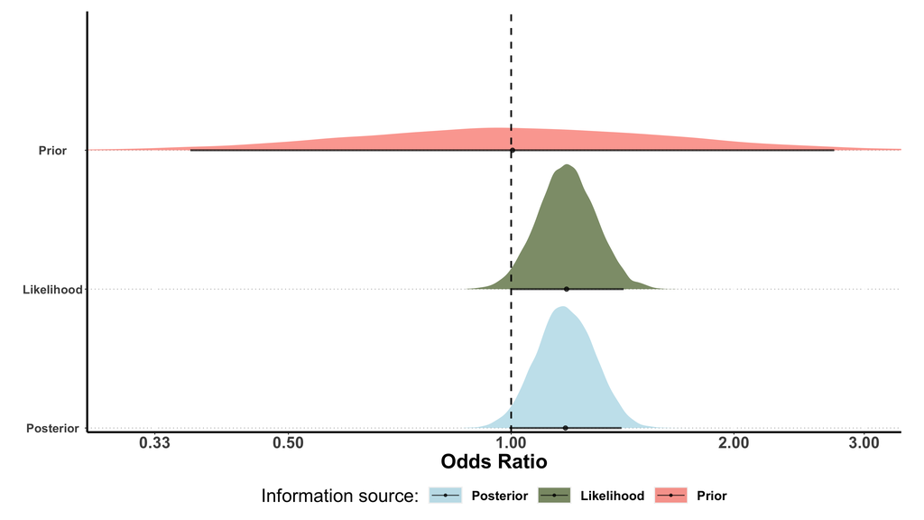

```r
###Figure 2

#First, let us create a dataframe containing the above 3 simulations
sims <- data.frame(sim_lnor = c(prior_sim, mint_sim, post_sim), #This column contains the results of our simulations (each of length 10,000)
           sim_type = rep(c("Prior", "Likelihood", "Posterior"), each = 10000) #This column contains the labels of these simulations so we can identify which simulation each row belongs to
           )

#Arrange sim_type so that it shows up with the prior on top, the posterior at the bottom, and likelihood in the middle.
sims$sim_type <- factor(sims$sim_type, levels = c("Posterior", "Likelihood", "Prior"))


#Now, let us visualize this:
#Plot
ggplot(data = sims,
       aes(y = sim_type,
           x = exp(sim_lnor),
           fill = sim_type
       )) +
  #Add Density plots
  stat_halfeye(alpha = 0.7, .width = 0.95) +
  #Set colors
  scale_fill_manual(name = "Information source:",
                    values = c("lightblue", "darkolivegreen", "salmon")) +
  geom_vline(xintercept = 1, color = "black",
             lwd = 1, linetype = 2) +
  #Set x-axis limit
  coord_cartesian(xlim = c(0.3, 3)) +
  #X and Y axes aesthetics
  scale_y_discrete(name = NULL, expand = c(0, 0.03)) +
  scale_x_continuous(name = "Odds Ratio",
                     trans = "log",
                     breaks = c(0.33, 0.5,1, 2, 3)) +
  #Set theme
  theme_pubclean() +
  theme(text = element_text(size = 23),
        plot.title=element_text(face = "bold", hjust = 0.0, size = 18),
        plot.subtitle = element_text(face = "bold", size = 10, hjust = 0.0, color = "grey45"),
        axis.text.x = element_text(size = 20, face = "bold"),
        axis.text.y = element_text(size = 15, face = "bold", hjust = 0.5),
        axis.title.x = element_text(size = 25, face = "bold"),
        axis.title.y = element_blank(),
        axis.line = element_line(colour = "black", linewidth = 1.2),
        plot.margin = margin(0.5, 1, 0.5, 1, "cm"),
        legend.background = element_rect(fill = "transparent"),
        legend.position = "bottom",
        legend.text = element_text(size = 16, face = "bold"),
        legend.key.width = unit(1.5, "cm"),
        legend.key.height = unit(0.75, "cm")
        )
```

# **Converting treatment effects to meaningful clinical quantities**

Here is the posterior distribution shown above:

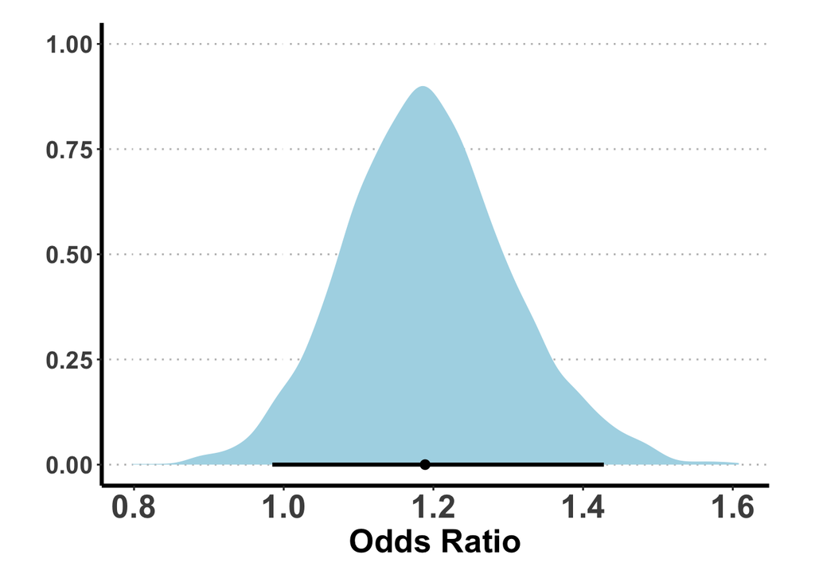

```r
fixef(mint_model, summary = F) |>
  data.frame() |>
  select(2) |>
  mutate(OR = exp(restrictive)) |>

  ggplot() +
  aes(x = OR) +
  stat_halfeye(.width = 0.95, fill = "lightblue") +
  #scale_x_continuous(breaks = seq(-2, 8, 2)) +
 # coord_cartesian(x = c(-3, 8)) +
  labs(x = "Odds Ratio") +
  theme_pubclean() +
  theme(text = element_text(size = 23),
        plot.title=element_text(face = "bold", hjust = 0.0, size = 18),
        plot.subtitle = element_text(face = "bold", size = 10, hjust = 0.0, color = "grey45"),
        axis.text.x = element_text(size = 20, face = "bold"),
        axis.text.y = element_text(size = 15, face = "bold", hjust = 0.5),
        axis.title.x = element_text(size = 20, face = "bold"),
        axis.title.y = element_blank(),
        axis.line = element_line(colour = "black", linewidth = 1.2),
        plot.margin = margin(0.5, 1, 0.5, 1, "cm"),
        legend.background = element_rect(fill = "transparent"),
        legend.position = "bottom",
        legend.text = element_text(size = 16, face = "bold"),
        legend.key.width = unit(1.5, "cm"),
        legend.key.height = unit(0.75, "cm")
        )
```

And this is the derived posterior distribution in the absolute risk difference scale:

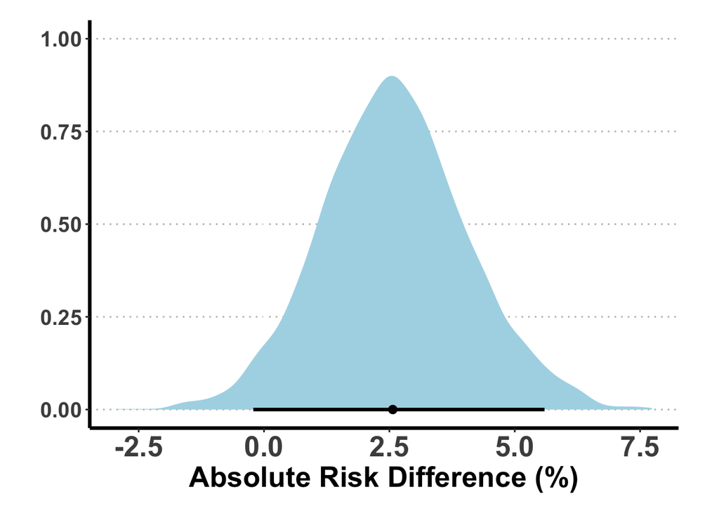

```r
# Equation 10 in https://doi.org/10.1016/j.jclinepi.2020.08.019

ARD_fun = function(R0, OR){
(R0*(R0-1)*(OR-1))/(R0*OR - R0 + 1)

}

fixef(mint_model, summary = F) |>
  data.frame() |>
  select(2) |>
  # multiply by 100 to convert to %, and by -1 since, in this example, ARD > 0
  # means that the restrictive arm is harmful
  mutate(ARD = -1*100*ARD_fun(R0 = baseline_risk, OR = exp(restrictive))) |>

  ggplot() +
  aes(x = ARD) +
  stat_halfeye(.width = 0.95, fill = "lightblue") +
  scale_x_continuous(breaks = seq(-2.5, 7.5, 2.5)) +
 # coord_cartesian(x = c(-3, 8)) +
  labs(x = "Absolute Risk Difference (%)") +
  theme_pubclean() +
  theme(text = element_text(size = 23),
        plot.title=element_text(face = "bold", hjust = 0.0, size = 18),
        plot.subtitle = element_text(face = "bold", size = 10, hjust = 0.0, color = "grey45"),
        axis.text.x = element_text(size = 20, face = "bold"),
        axis.text.y = element_text(size = 15, face = "bold", hjust = 0.5),
        axis.title.x = element_text(size = 20, face = "bold"),
        axis.title.y = element_blank(),
        axis.line = element_line(colour = "black", linewidth = 1.2),
        plot.margin = margin(0.5, 1, 0.5, 1, "cm"),
        legend.background = element_rect(fill = "transparent"),
        legend.position = "bottom",
        legend.text = element_text(size = 16, face = "bold"),
        legend.key.width = unit(1.5, "cm"),
        legend.key.height = unit(0.75, "cm")
        )
```

Finally, we will now calculate the posterior probability of all possible levels of efficacy. We highlight the originally chosen MCID of 1.8%.

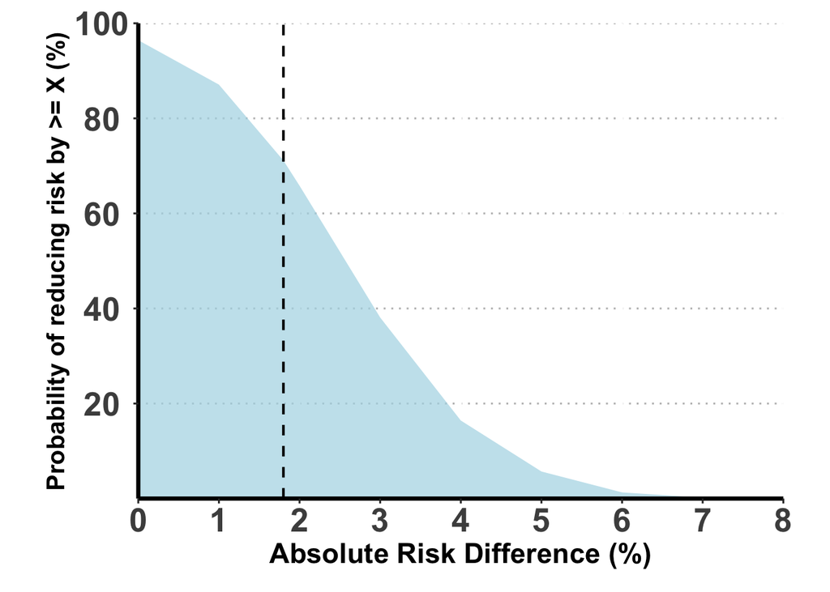

```r
#Now we will do something more useful: We will calculate the probability that liberal exerts a protective effect for a range of risk reductions ranging from any reduction at all to completely eliminating the risk of death/MI

#Range of MCIDs in which we may be interested (from 0% to fully eliminating the baseline risk, 0.01% at a time)
mcids <- c(0.018, seq(0, baseline_risk, 0.01))

#Set up an empty dataframe to store our probabilities
cum_postd <- data.frame()

#Set up a loop to replicate the analysis above for every single mcid stored in mcids
for(mcid in mcids) {

  #Therefore, the risk in the intervention arm ought to be:
  greater_risk <- baseline_risk + mcid

  #The formula to convert from risk (probability) to odds is: R / (1 - R)
  baseline_odds <- baseline_risk / (1 - baseline_risk)
  greater_odds <- greater_risk / (1 - greater_risk)

  #Therefore, if the intervention provides a MCID, the odds ratio should be at least:
  minimum_relevant_or <- greater_odds/baseline_odds


  question <- paste0("restrictive > ", log(minimum_relevant_or))

  #And we use the hypothesis function to find out
  effect <- hypothesis(mint_model, #Our model
                       hypothesis = question) #The log-odds ratio to use


  cum_postd <- rbind(cum_postd, #The empty dataframe we created above

                     data.frame( #The dataframe we created using data in this loop
                       difference = mcid, #The log-odds ratio we used
                       post_probs = effect$hypothesis$Post.Prob) #The posterior probability
  )
}

cum_postd |>

  ggplot(aes(y = post_probs*100, #Multiply by 100 to convert to % (to facilitate interpretation)
           x = difference*100, #Multiply by 100 to convert to % (to facilitate interpretation)
           fill = ifelse(difference >= 0, "Positive", "Negative"))
       ) +

#Add Density plots
    #Add Density plots
  geom_area(fill = "lightblue",
            alpha = 0.7) +
  #Set colors
  #Plot a vertical line at a MCID of 1.8%
  geom_vline(xintercept = 1.8, color = "black",
             lwd = 0.75, linetype = 2) +
  #X and Y axes aesthetics
  scale_y_continuous(name = "Probability of reducing risk by >= X (%)",
                     expand = c(0, 0),
                     breaks = seq(20, 100, 20)) +
  scale_x_continuous(name = "Absolute Risk Difference (%)",
                     expand = c(0, 0),
                     breaks = seq(0, 8, 1)) +
  #Set coordinate limits
  coord_cartesian(ylim = c(0, 100),
                  xlim = c(0, 8)) +
  #Set theme
  theme_pubclean() +
  theme(text = element_text(size = 23),
        plot.title=element_text(face = "bold", hjust = 0.0, size = 18),
        plot.subtitle = element_text(face = "bold", size = 10, hjust = 0.0, color = "grey45"),
        axis.text.x = element_text(size = 20, face = "bold"),
        axis.text.y = element_text(size = 20, face = "bold", hjust = 0.5),
        axis.title.x = element_text(size = 17, face = "bold"),
        axis.title.y = element_text(size = 15, face = "bold"),
        axis.line = element_line(colour = "black", linewidth = 1.2),
        plot.margin = margin(0.5, 1, 0.5, 1, "cm"),
        legend.background = element_rect(fill = "transparent"),
        legend.position = "none"
        )
```

# **Using Bayesian analyses to inform personalized treatment decisions**

Let’s perform the same calculations shown above, but with different baseline risks.

```r
##To facilitate the calculation of meaningful risk reductions in Death/MI across different risk levels. We will convert the for loop we created above to a function that can incorporate our baseline risks of interest and the MCIDs of interest


# Harm analyses

calculate_cum_post_prob <- function(baseline_risks, mcids, brm_model) {

  #Set up an empty dataframe to store our probabilities
  cum_post_probs_df <- data.frame()

  #Set up a for loop to replicate the analysis below for every baseline risk of interest

  for(baseline_risk in baseline_risks) {

    #Set up a (nested) for loop to replicate the analysis below for every single mcid stored in mcids
    for(mcid in mcids[mcids < baseline_risk]) {

      #Therefore, the risk in the intervention arm ought to be:
      greater_risk <- baseline_risk + mcid

      #The formula to convert from risk (probability) to odds is: R / (1 - R)
      baseline_odds <- baseline_risk / (1 - baseline_risk)
      greater_odds <- greater_risk / (1 - greater_risk)

      #Therefore, if the intervention provides a MCID, the odds ratio should be at least:
      minimum_relevant_or <- greater_odds/baseline_odds


      question <- paste0("restrictive > ", log(minimum_relevant_or))

      #And we use the hypothesis function to find out
      effect <- hypothesis(brm_model, #Our model
                           hypothesis = question) #The log-odds ratio to use


      cum_post_probs_df <- rbind(cum_post_probs_df, #The empty dataframe we created above

                         data.frame( #The dataframe we created using data in this loop
                           difference = mcid, #The user-specified MCID
                           post_probs = effect$hypothesis$Post.Prob, #The posterior probability as returned by the model
                           baseline_risk = baseline_risk) #The user-specified baseline risk
      )
    }
  }
  #Return the output
  cum_post_probs_df
}


#Calcualte the probability of benefit across 6 different baseline risks and store them

ard_probabilities <- calculate_cum_post_prob(baseline_risks = seq(0.1, 0.2, 0.02),
                        mcids = seq(0, 0.1, 0.01), #Spectrum of risk differences
                        brm_model = mint_model) #Our model
```

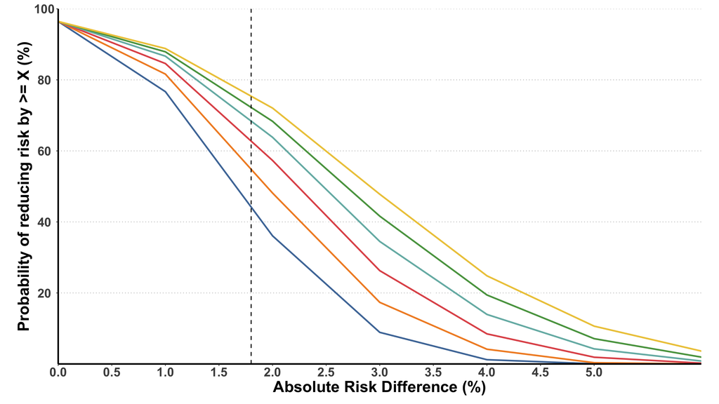

```r
#Now, let's plot our results:
ggplot(data = ard_probabilities,
       aes(y = post_probs*100, #Multiply by 100 to convert to % (to facilitate interpretation)
           x = difference*100, #Multiply by 100 to convert to % (to facilitate interpretation)
           color = factor(baseline_risk*100),
           group = baseline_risk
       )) +
  #Add Density plots
    #Add Density plots
  geom_line(linewidth = 1.25) +
  #Set colors
  scale_color_tableau(name = "Baseline risk (%)") +
  #Plot a vertical line at a MCID of 1.8%
  geom_vline(xintercept = 1.8, color = "black",
             lwd = 0.75, linetype = 2) +
  #X and Y axes aesthetics
  scale_y_continuous(name = "Probability of reducing risk by >= X (%)",
                     expand = c(0, 0),
                     breaks = seq(20, 100, 20)) +
  scale_x_continuous(name = "Absolute Risk Difference (%)",
                     expand = c(0, 0),
                     breaks = seq(0, 5, 0.5)) +
  #Set limits on the Y-axis
  coord_cartesian(ylim = c(0, 100),
                  xlim = c(0, 6)) +
  #Set theme
  theme_pubclean() +
  theme(text = element_text(size = 23),
        plot.title=element_text(face = "bold", hjust = 0.0, size = 18),
        plot.subtitle = element_text(face = "bold", size = 10, hjust = 0.0, color = "grey45"),
        axis.text.x = element_text(size = 20, face = "bold"),
        axis.text.y = element_text(size = 20, face = "bold", hjust = 0.5),
        axis.title.x = element_text(size = 25, face = "bold"),
        axis.title.y = element_text(size = 25, face = "bold"),
        axis.line = element_line(colour = "black", linewidth = 1.2),
        plot.margin = margin(0.5, 1, 0.5, 1, "cm"),
        legend.background = element_rect(fill = "transparent"),
        legend.position = "none"
        ) +
  guides(color = guide_legend(nrow = 1))
```

# *Different priors*

Code with all models:

```r
# Function from https://hbiostat.org/r/examples/rmsbgraphicsvignette/graphics
normsolve <- function (myvalue, myprob = 0.025, mu=0, convert2 =c("none", "log", "logodds")){
  ## modified bbr's normsolve()
  ## normsolve() solves for SD (of a normal distribution) such that the tail (area) probability beyond myvalue is myprob
  ## myprob = tail area probability
  ## convert2() converts mu and myvalue to the scale of the normal distribution
  ## If mu and myvalue are OR values, use "log" to convert them to log(OR)
  ## If mu and myvalue are prob values, use "logodds" to convert them to log(odds)

  if (missing(convert2)) {convert2 <-  "none"}
  if (convert2=="log" & mu==0) {
    cat ("Note: mu cannot be 0 so setting an arbitrary value of 1.0")
    mu = 1
  }
  mysd <- switch(convert2,
                 "none" = (myvalue-mu)/qnorm(1-myprob),
                 "log" =  (log(myvalue)- log(mu))/qnorm(1-myprob),
                 "logodds" = (qlogis(myvalue)- qlogis(mu))/qnorm(1-myprob)   )
  return(mysd)
}



#The skeptical mean is centered on 0


skepitcal_prior_mean <- 0

#Find the SD of a normal distribution with a mean 0 such that the probability of a clinically meaningful benefit (ARR > or equal to 1.8% corresponding to an OR of 1.13 or less as previously shown) is 10%.

skeptical_prior_sd = normsolve(myvalue = log(min_or), myprob =  0.1,
                               mu = skepitcal_prior_mean,
                               convert2 = "none")

#Create your skeptical prior
skeptical_prior <- prior(normal(skepitcal_prior_mean, skeptical_prior_sd))

#The enthusiastic mean is centered on the minimal clinically relevant difference (in this case, the OR corresponding to said difference)
enthusiastic_prior_mean <- log(min_or)

#The enthusiastic SD gives a 70% probability of benefit (versus 30% of harm)
enthusiastic_prior_sd = normsolve(myvalue = 0, myprob =  0.7,
                                  mu = enthusiastic_prior_mean,
                               convert2 = "none")

#Create your enthusiastic prior
enthusiastic_prior <- prior(normal(enthusiastic_prior_mean, enthusiastic_prior_sd))

#Create your pessimistic prior
# This prior has the same SD as the enthusiastic and the opposite mean value

pessimistic_prior <- prior(normal(-enthusiastic_prior_mean, enthusiastic_prior_sd))

##Let us construct a "noninf/non-informative" prior
#This will be done using a normal distribution at a mean of 0 and with a large SD of 10. This allows relatively large probabilities of extremely large (and unrealistic) treatment effects. It is (roughly) equivalent to allowing the data/likelihood to completely dictate your posterior as you discard all prior knowledge as irrelevant to assessing the results of MINT
noninf_prior_mean <- 0
noninf_prior_sd <- 10

#Create your noninformative prior
noninf_prior <- prior(normal(noninf_prior_mean, noninf_prior_sd))

#Now, we will reuse the same formula as before
mint_formula <- bf(
  events_n | trials(total_n) ~
    1 + #Add an intercept to our model (for the baseline risk in the control group)
    restrictive) #Treatment effect of restrictive


##Now, we will perform the analysis using the skeptical and enthusiastic prior.

if(!exists("skeptical_mint_model")) {
#Run the model incorporating the data from PROTECT TAVR under a skepitcal prior
skeptical_mint_model <- brm(data = mint_data, #Use the dataset from PROTECT TAVR
               family = binomial, #Using a binomial distribution (Since our outcome is a binary Stroke/No stroke)
               formula = mint_formula, #Use our formula
               seed = 100, #Set seed for reproducibility
               prior = skeptical_prior,
               stanvars = stanvar(skepitcal_prior_mean) + stanvar(skeptical_prior_sd), #We pass the variable names used in our priors here so that Stan recognizes them
               backend = "cmdstanr",
               refresh = 0
               )
}
```

```
Running MCMC with 4 chains, at most 8 in parallel...

Chain 1 finished in 0.0 seconds.
Chain 2 finished in 0.0 seconds.
Chain 3 finished in 0.0 seconds.
Chain 4 finished in 0.0 seconds.

All 4 chains finished successfully.
Mean chain execution time: 0.0 seconds.
Total execution time: 0.2 seconds.
```

```r
if(!exists("enthusiastic_mint_model")) {
#Run the model incorporating the data from PROTECT TAVR under an enthusiastic prior
enthusiastic_mint_model <- brm(data = mint_data, #Use the dataset from PROTECT TAVR
               family = binomial, #Using a binomial distribution (Since our outcome is a binary Stroke/No stroke)
               formula = mint_formula, #Use our formula
               seed = 100, #Set seed for reproducibility
               prior = enthusiastic_prior,
               stanvars = stanvar(enthusiastic_prior_mean) + stanvar(enthusiastic_prior_sd), #We pass the variable names used in our priors here so that Stan recognizes them
               backend = "cmdstanr",
               refresh = 0
               )
}
```

```
Running MCMC with 4 chains, at most 8 in parallel...

Chain 1 finished in 0.0 seconds.
Chain 2 finished in 0.0 seconds.
Chain 3 finished in 0.0 seconds.
Chain 4 finished in 0.0 seconds.

All 4 chains finished successfully.
Mean chain execution time: 0.0 seconds.
Total execution time: 0.2 seconds.
```

```r
if(!exists("pessimistic_mint_model")) {
#Run the model incorporating the data from PROTECT TAVR under an enthusiastic prior
pessimistic_mint_model <- brm(data = mint_data, #Use the dataset from PROTECT TAVR
               family = binomial, #Using a binomial distribution (Since our outcome is a binary Stroke/No stroke)
               formula = mint_formula, #Use our formula
               seed = 100, #Set seed for reproducibility
               prior = pessimistic_prior,
               stanvars = stanvar(enthusiastic_prior_mean) + stanvar(enthusiastic_prior_sd), #We pass the variable names used in our priors here so that Stan recognizes them
               backend = "cmdstanr",
               refresh = 0
               )
}
```

```
Running MCMC with 4 chains, at most 8 in parallel...

Chain 1 finished in 0.0 seconds.
Chain 2 finished in 0.0 seconds.
Chain 3 finished in 0.0 seconds.
Chain 4 finished in 0.0 seconds.

All 4 chains finished successfully.
Mean chain execution time: 0.0 seconds.
Total execution time: 0.2 seconds.
```

```r
if(!exists("noninf_mint_model")) {
#Run the model incorporating the data from PROTECT TAVR under a noninf prior
noninf_mint_model <- brm(data = mint_data, #Use the dataset from PROTECT TAVR
               family = binomial, #Using a binomial distribution (Since our outcome is a binary Stroke/No stroke)
               formula = mint_formula, #Use our formula
               seed = 100, #Set seed for reproducibility
               prior = noninf_prior, #Use the prior based on the meta-analysis
               stanvars = stanvar(noninf_prior_mean) + stanvar(noninf_prior_sd), #We pass the variable names used in our priors here so that Stan recognizes them
               backend = "cmdstanr",
               refresh = 0
               )
}
```

```
Running MCMC with 4 chains, at most 8 in parallel...

Chain 1 finished in 0.0 seconds.
Chain 2 finished in 0.0 seconds.
Chain 3 finished in 0.0 seconds.
Chain 4 finished in 0.0 seconds.

All 4 chains finished successfully.
Mean chain execution time: 0.0 seconds.
Total execution time: 0.2 seconds.
```

```r
##Obtain posterior probability of effect under the 2 models
#Skeptic
skeptical_prob_any_effect <- hypothesis(skeptical_mint_model,
                                         "restrictive > 0")
skeptical_prob_any_effect <- round(skeptical_prob_any_effect$hypothesis$Post.Prob*100, 2)
#Enthusiastic
enthusiastic_prob_any_effect <- hypothesis(enthusiastic_mint_model,
                                         "restrictive > 0")
enthusiastic_prob_any_effect <- round(enthusiastic_prob_any_effect$hypothesis$Post.Prob*100, 2)
#pessimistic
pessimistic_prob_any_effect <- hypothesis(pessimistic_mint_model,
                                         "restrictive > 0")
pessimistic_prob_any_effect <- round(pessimistic_prob_any_effect$hypothesis$Post.Prob*100, 2)
#Non-informative
noninf_prob_any_effect <- hypothesis(noninf_mint_model,
                                         "restrictive > 0")
noninf_prob_any_effect <- round(noninf_prob_any_effect$hypothesis$Post.Prob*100, 2)
##Obtain posterior probability of important effect under the 2 models
#Skeptic
skeptical_prob_imp_effect <- hypothesis(skeptical_mint_model,
                                         paste0("restrictive > ", log(min_or)))
skeptical_prob_imp_effect <- round(skeptical_prob_imp_effect$hypothesis$Post.Prob*100, 2)
#Enthusiastic
enthusiastic_prob_imp_effect <- hypothesis(enthusiastic_mint_model,
                                         paste0("restrictive > ", log(min_or)))
enthusiastic_prob_imp_effect <- round(enthusiastic_prob_imp_effect$hypothesis$Post.Prob*100, 2)
#pessimistic
pessimistic_prob_imp_effect <- hypothesis(pessimistic_mint_model,
                                         paste0("restrictive > ", log(min_or)))
pessimistic_prob_imp_effect <- round(pessimistic_prob_imp_effect$hypothesis$Post.Prob*100, 2)
#Non-informative
noninf_prob_imp_effect <- hypothesis(noninf_mint_model,
                                         paste0("restrictive > ", log(min_or)))
noninf_prob_imp_effect <- round(noninf_prob_imp_effect$hypothesis$Post.Prob*100, 2)

## Harm analyses

#Obtain posterior probability of effect under the 2 models
#Skeptic
skeptical_prob_any_harm_effect <- hypothesis(skeptical_mint_model,
                                        "restrictive < 0")
skeptical_prob_any_harm_effect <- round(skeptical_prob_any_harm_effect$hypothesis$Post.Prob*100, 2)
#Enthusiastic
enthusiastic_prob_any_harm_effect <- hypothesis(enthusiastic_mint_model,
                                           "restrictive < 0")
enthusiastic_prob_any_harm_effect <- round(enthusiastic_prob_any_harm_effect$hypothesis$Post.Prob*100, 2)
#pessimistic
pessimistic_prob_any_harm_effect <- hypothesis(pessimistic_mint_model,
                                           "restrictive < 0")
pessimistic_prob_any_harm_effect <- round(pessimistic_prob_any_harm_effect$hypothesis$Post.Prob*100, 2)
#Non-informative
noninf_prob_any_harm_effect <- hypothesis(noninf_mint_model,
                                     "restrictive < 0")
noninf_prob_any_harm_effect <- round(noninf_prob_any_harm_effect$hypothesis$Post.Prob*100, 2)
##Obtain posterior probability of important effect under the 2 models
#Skeptic
skeptical_prob_harm_imp_effect <- hypothesis(skeptical_mint_model,
                                        paste0("restrictive < ", -log(min_or)))
skeptical_prob_harm_imp_effect <- round(skeptical_prob_harm_imp_effect$hypothesis$Post.Prob*100, 2)
#Enthusiastic
enthusiastic_prob_harm_imp_effect <- hypothesis(enthusiastic_mint_model,
                                           paste0("restrictive < ", -log(min_or)))
enthusiastic_prob_harm_imp_effect <- round(enthusiastic_prob_harm_imp_effect$hypothesis$Post.Prob*100, 2)
#pessimistic
pessimistic_prob_harm_imp_effect <- hypothesis(pessimistic_mint_model,
                                           paste0("restrictive < ", -log(min_or)))
pessimistic_prob_harm_imp_effect <- round(pessimistic_prob_harm_imp_effect$hypothesis$Post.Prob*100, 2)
#Non-informative
noninf_prob_harm_imp_effect <- hypothesis(noninf_mint_model,
                                     paste0("restrictive < ", -log(min_or)))
noninf_prob_harm_imp_effect <- round(noninf_prob_harm_imp_effect$hypothesis$Post.Prob*100, 2)
```

```r
# MCID = 0.01

#Skeptic
skeptical_prob_imp_effect1 <- hypothesis(skeptical_mint_model,
                                        paste0("restrictive > ", log(min_or1)))
skeptical_prob_imp_effect1 <- round(skeptical_prob_imp_effect1$hypothesis$Post.Prob*100, 2)
#Enthusiastic
enthusiastic_prob_imp_effect1 <- hypothesis(enthusiastic_mint_model,
                                           paste0("restrictive > ", log(min_or1)))
enthusiastic_prob_imp_effect1 <- round(enthusiastic_prob_imp_effect1$hypothesis$Post.Prob*100, 2)
#pessimistic
pessimistic_prob_imp_effect1 <- hypothesis(pessimistic_mint_model,
                                          paste0("restrictive > ", log(min_or1)))
pessimistic_prob_imp_effect1 <- round(pessimistic_prob_imp_effect1$hypothesis$Post.Prob*100, 2)
#Non-informative
noninf_prob_imp_effect1 <- hypothesis(noninf_mint_model,
                                     paste0("restrictive > ", log(min_or1)))
noninf_prob_imp_effect1 <- round(noninf_prob_imp_effect1$hypothesis$Post.Prob*100, 2)

## Harm analyses

#Skeptic
skeptical_prob_harm_imp_effect1 <- hypothesis(skeptical_mint_model,
                                             paste0("restrictive < ", -log(min_or1)))
skeptical_prob_harm_imp_effect1 <- round(skeptical_prob_harm_imp_effect1$hypothesis$Post.Prob*100, 2)
#Enthusiastic
enthusiastic_prob_harm_imp_effect1 <- hypothesis(enthusiastic_mint_model,
                                                paste0("restrictive < ", -log(min_or1)))
enthusiastic_prob_harm_imp_effect1 <- round(enthusiastic_prob_harm_imp_effect1$hypothesis$Post.Prob*100, 2)
#pessimistic
pessimistic_prob_harm_imp_effect1 <- hypothesis(pessimistic_mint_model,
                                               paste0("restrictive < ", -log(min_or1)))
pessimistic_prob_harm_imp_effect1 <- round(pessimistic_prob_harm_imp_effect1$hypothesis$Post.Prob*100, 2)
#Non-informative
noninf_prob_harm_imp_effect1 <- hypothesis(noninf_mint_model,
                                          paste0("restrictive < ", -log(min_or1)))
noninf_prob_harm_imp_effect1 <- round(noninf_prob_harm_imp_effect1$hypothesis$Post.Prob*100, 2)
```

Here is the summary of all priors applied in the following analyses:

```r
tribble(
  ~"Prior", ~"Mean", ~"SD",
  "Literature-based ", treatment_effect[,"Estimate"], treatment_effect[,"Est.Error"],
  "Non-informative", noninf_prior_mean, noninf_prior_sd,
  "Skeptical", skepitcal_prior_mean, skeptical_prior_sd,
  "Enthusiastic", enthusiastic_prior_mean, enthusiastic_prior_sd,
  "Pessimistic", -enthusiastic_prior_mean, enthusiastic_prior_sd
) |>
  gt()
```

| Prior | Mean | SD |
| --- | --- | --- |
| Literature-based | 0.009266136 | 0.51211190 |
| Non-informative | 0.000000000 | 10.00000000 |
| Skeptical | 0.000000000 | 0.09620315 |
| Enthusiastic | 0.123289299 | 0.23510522 |
| Pessimistic | -0.123289299 | 0.23510522 |

# **Summary results**

MCID of 1.8%

```r
tribble(
  ~"Prior", ~"Pr(Any benefit)", ~"Pr(MCID benefit)", ~"Pr(Any harm)", ~"Pr(MCID harm)",
  "Literature-based ", post_prob_any_effect, post_prob_mcid, post_prob_any_harm_effect, post_prob_harm_mcid,
  "Non-informative", noninf_prob_any_effect, noninf_prob_imp_effect, noninf_prob_any_harm_effect, noninf_prob_harm_imp_effect,
  "Skeptical", skeptical_prob_any_effect, skeptical_prob_imp_effect, skeptical_prob_any_harm_effect, skeptical_prob_harm_imp_effect,
  "Enthusiastic", enthusiastic_prob_any_effect, enthusiastic_prob_imp_effect, enthusiastic_prob_any_harm_effect, enthusiastic_prob_harm_imp_effect,
  "Pessimistic", pessimistic_prob_any_effect, pessimistic_prob_imp_effect, pessimistic_prob_any_harm_effect, pessimistic_prob_harm_imp_effect
) |>
  gt() |>
  tab_footnote(footnote = "Restrictive strategy is the control arm. An OR greater than 1 represents that the liberal strategy is better than restrictive.") |>
  tab_footnote(footnote = "Assumed control arm risk = 16.9%") |>
  tab_footnote(footnote = "Pr(Any benefit) = Pr(OR > 1.0) = Pr(ARD > 0%)") |>
  tab_footnote(footnote = "Pr(MCID benefit) = Pr(OR > 1.13) = Pr(ARD > 1.8%)") |>
  tab_footnote(footnote = "Pr(Any harm) = Pr(OR < 1.0) = Pr(ARD < 0%)") |>
  tab_footnote(footnote = "Pr(MCID harm) = Pr(OR < 0.88) = Pr(ARD < 1.8%)")
```

| Prior | Pr(Any benefit) | Pr(MCID benefit) | Pr(Any harm) | Pr(MCID harm) |
| --- | --- | --- | --- | --- |
| Literature-based | 96.45 | 71.12 | 3.55 | 0.20 |
| Non-informative | 97.32 | 71.00 | 2.67 | 0.03 |
| Skeptical | 92.42 | 31.90 | 7.58 | 0.08 |
| Enthusiastic | 97.40 | 70.05 | 2.60 | 0.03 |
| Pessimistic | 94.85 | 56.57 | 5.15 | 0.10 |

Restrictive strategy is the control arm. An OR greater than 1 represents that the liberal strategy is better than restrictive.  
Assumed control arm risk = 16.9%  
Pr(Any benefit) = Pr(OR > 1.0) = Pr(ARD > 0%)  
Pr(MCID benefit) = Pr(OR > 1.13) = Pr(ARD > 1.8%)  
Pr(Any harm) = Pr(OR < 1.0) = Pr(ARD < 0%)  
Pr(MCID harm) = Pr(OR < 0.88) = Pr(ARD < 1.8%)

MCID of 1%

```r
tribble(
  ~"Prior", ~"Pr(Any benefit)", ~"Pr(MCID benefit)", ~"Pr(Any harm)", ~"Pr(MCID harm)",
  "Literature-based ", post_prob_any_effect, post_prob_mcid1, post_prob_any_harm_effect, post_prob_harm_mcid1,
  "Non-informative", noninf_prob_any_effect, noninf_prob_imp_effect1, noninf_prob_any_harm_effect, noninf_prob_harm_imp_effect1,
  "Skeptical", skeptical_prob_any_effect, skeptical_prob_imp_effect1, skeptical_prob_any_harm_effect, skeptical_prob_harm_imp_effect1,
  "Enthusiastic", enthusiastic_prob_any_effect, enthusiastic_prob_imp_effect1, enthusiastic_prob_any_harm_effect, enthusiastic_prob_harm_imp_effect1,
  "Pessimistic", pessimistic_prob_any_effect, pessimistic_prob_imp_effect1, pessimistic_prob_any_harm_effect, pessimistic_prob_harm_imp_effect1
) |>
  gt() |>
  tab_footnote(footnote = "Restrictive strategy is the control arm. An OR greater than 1 represents that the liberal strategy is better than restrictive.") |>
  tab_footnote(footnote = "Assumed control arm risk = 16.9%") |>
  tab_footnote(footnote = "Pr(Any benefit) = Pr(OR > 1.0) = Pr(ARD > 0%)") |>
  tab_footnote(footnote = "Pr(MCID benefit) = Pr(OR > 1.07) = Pr(ARD > 1%)") |>
  tab_footnote(footnote = "Pr(Any harm) = Pr(OR < 1.0) = Pr(ARD < 0%)") |>
  tab_footnote(footnote = "Pr(MCID harm) = Pr(OR < 0.93) = Pr(ARD < 1%)")
```

| Prior | Pr(Any benefit) | Pr(MCID benefit) | Pr(Any harm) | Pr(MCID harm) |
| --- | --- | --- | --- | --- |
| Literature-based | 96.45 | 87.10 | 3.55 | 0.73 |
| Non-informative | 97.32 | 86.83 | 2.67 | 0.35 |
| Skeptical | 92.42 | 63.42 | 7.58 | 0.55 |
| Enthusiastic | 97.40 | 86.85 | 2.60 | 0.37 |
| Pessimistic | 94.85 | 78.55 | 5.15 | 0.78 |

Restrictive strategy is the control arm. An OR greater than 1 represents that the liberal strategy is better than restrictive.  
Assumed control arm risk = 16.9%  
Pr(Any benefit) = Pr(OR > 1.0) = Pr(ARD > 0%)  
Pr(MCID benefit) = Pr(OR > 1.07) = Pr(ARD > 1%)  
Pr(Any harm) = Pr(OR < 1.0) = Pr(ARD < 0%)  
Pr(MCID harm) = Pr(OR < 0.93) = Pr(ARD < 1%)